# STSCI 5065 - Lecture 20

Hadoop and SAS Integration

Harry Lu

# 1 SAS Foundation Interfaces for Hadoop

[output not shown]

# 2 SAS In-Memory Analytics Interfaces for Hadoop

- Hadoop is now one of the file storage systems that SAS uses for SAS In-Memory Analytics product solutions:
  - SAS High-Performance Analytics products
  - SAS Visual Analytics
  - SAS In-Memory Statistics
  - SAS Code Accelerator for Hadoop (DS2)

## 2.1 A Hadoop Cluster to Run SAS

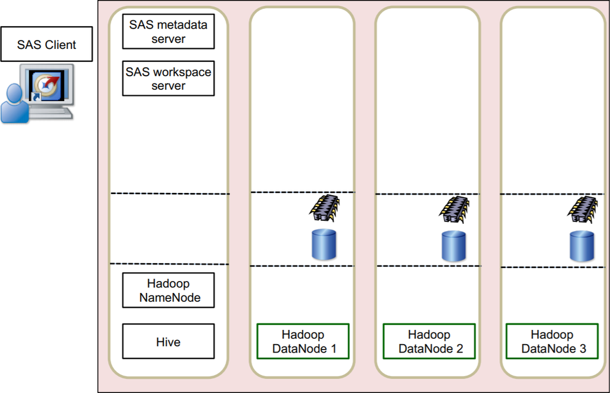

## 2.2 Base SAS: FILENAME for Hadoop

[figure not shown]

## 2.3 Base SAS: The Same Process for PROC HADOOP

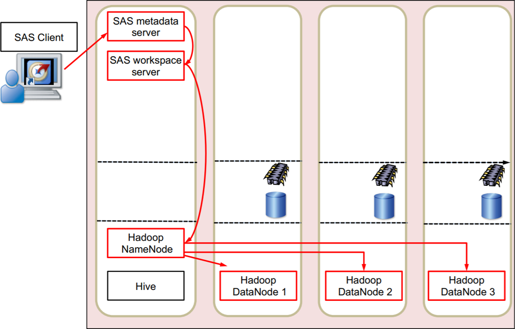

## 2.4 SAS/ACCESS: SQL Pass-Through and LIBNAME

[figure not shown]

## 2.5 In-Memory Analytics

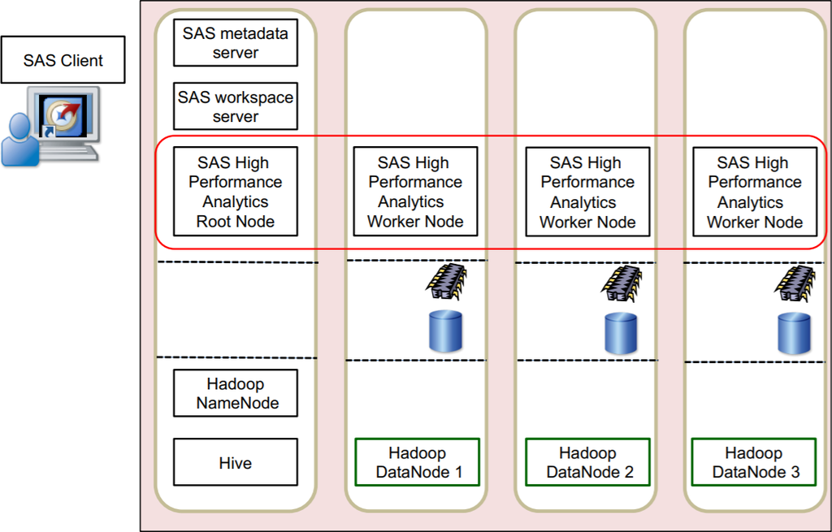

## 2.6 Computing Environment

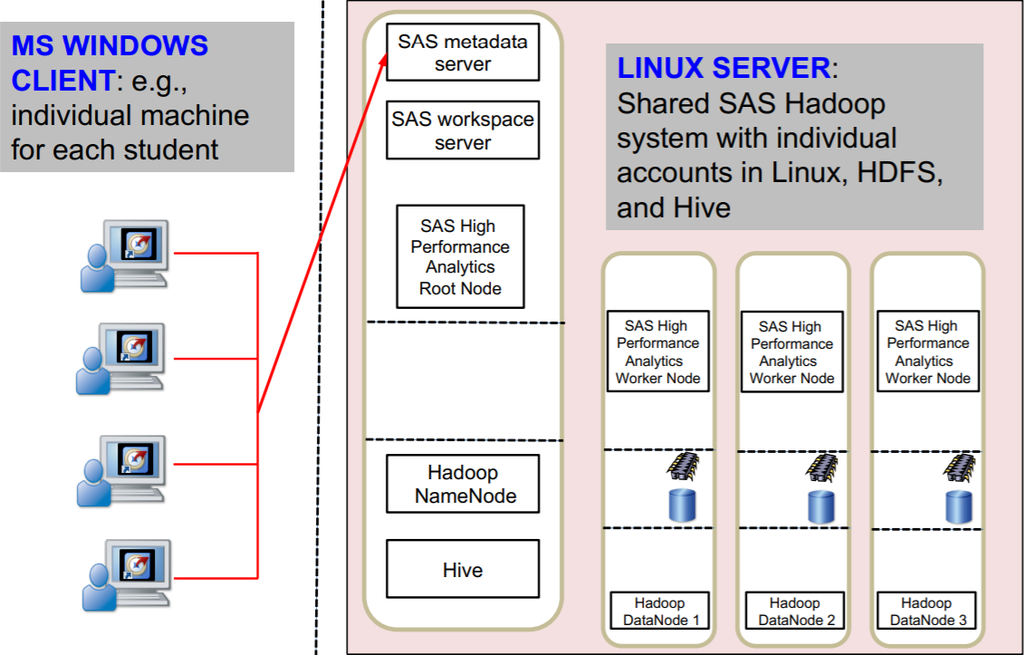

# 3 Managing Files and Executing Hadoop Commands, Map-Reduce, and Pig

- Part 1: Introduction to Base SAS Methods for Hadoop
- Part 2: The HADOOP FILENAME Statement and PROC HADOOP
- Part 3: Executing Pig Code With PROC HADOOP

# 4 Part 1: Introduction to Base SAS Methods for Hadoop

## 4.1 Base SAS Tools for Hadoop

- The Hadoop `FILENAME` statement enables you to do the following:
  - upload local data to Hadoop using the DATA step
  - read data from Hadoop using the DATA step
- `PROC HADOOP` enables you to do the following:
  - submit Hadoop file system (HDFS) commands
  - submit MapReduce programs
  - submit Pig script

## 4.2 The Hadoop `Config.xml` File

- The `FILENAME` statement for Hadoop and `PROC HADOOP` require an option that specifies **a Hadoop configuration file (`config.xml`)**.
  - The configuration file defines how to connect to Hadoop.
  - The file must be accessible to the SAS client application.
  - A SAS administrator commonly manages this configuration for the SAS users.
  - This file is often referred to as the **Hadoop core-site.xml** file.

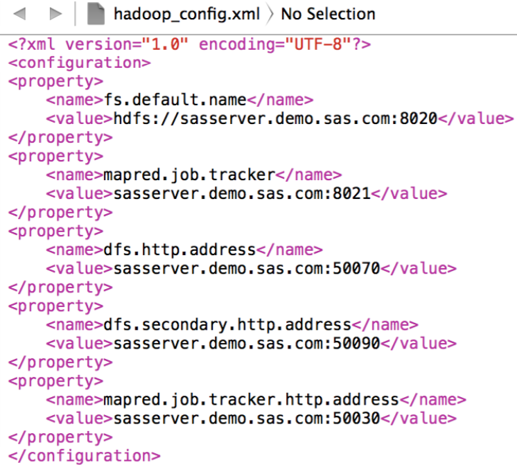

## 4.3 Hadoop JAR Files

- A collection of Hadoop JAR files is also required on the SAS client machine.
  - An **environment variable** `SAS_HADOOP_JAR_PATH` on the SAS **client machine** defines the location of the Hadoop JAR files
  - The Hadoop JAR files must be compatible with the specific Hadoop implementation and **can be copied from the Hadoop server**.
  - A Hadoop system administrator commonly manages the configuration of the Hadoop JAR files for the SAS users.

## 4.4 Base SAS Interface to Hadoop

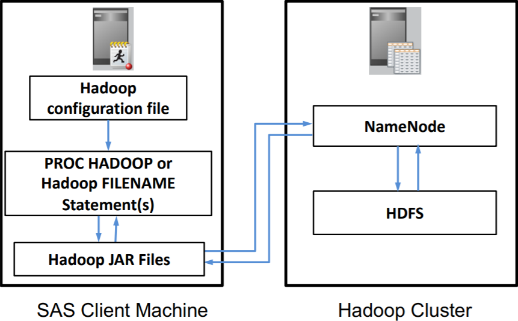

# 5 Part 2: The HADOOP FILENAME Statement and PROC HADOOP

## 5.1 Business Scenario

- We want to develop a prototype for a process that uses SAS to orchestrate the following scenario:
  1. Move unstructured text files into the Hadoop file system.
  2. Invoke MapReduce programs developed by Java programmers in order to:
     - read and process the text files to perform various analyses
     - output results as text files in the Hadoop file system
  3. Read the summarized text analysis results back into SAS for further analysis and reporting purposes.

### 5.1.1 Business Scenario 1

### 5.1.2 Business Scenario 2

### 5.1.3 Business Scenario 3

## 5.2 Business Scenario Pseudocode

## 5.3 PROC HADOOP

## 5.4 HDFS Statements

## 5.5 Moving a File from SAS to Hadoop

## 5.6 Execute MapReduce Code

### 5.6.1 Execute MapReduce Code 2

### 5.6.2 Execute MapReduce Code 3

### 5.6.3 Execute MapReduce Code 4

### 5.6.4 Execute MapReduce Code 5

## 5.7 MapReduce Example

### 5.7.1 MapReduce Example 2

### 5.7.2 MapReduce Example 3

### 5.7.3 MapReduce Example 4

### 5.7.4 MapReduce Example 5

### 5.7.5 MapReduce Example 6

### 5.7.6 MapReduce Example 7

### 5.7.7 MapReduce Example 8

## 5.8 The FILENAME Statement for Hadoop

### 5.8.1 The FILENAME Statement for Hadoop 2

### 5.8.2 The FILENAME Statement for Hadoop 3

### 5.8.3 The FILENAME Statement for Hadoop 4

### 5.8.4 The FILENAME Statement for Hadoop 5

### 5.8.5 The FILENAME Statement for Hadoop 6

### 5.8.6 The FILENAME Statement for Hadoop 7

## 5.9 Reading a Hadoop File with a DATA Step

### 5.9.1 Reading a Hadoop File with a DATA Step 2

### 5.9.2 Another Example

## 5.10 Base SAS: FILENAME for Hadoop (Review)

### 5.10.1 Reading a Hadoop File with a DATA Step 1

### 5.10.2 Reading a Hadoop File with a DATA Step 2

### 5.10.3 Reading a Hadoop File with a DATA Step 3

### 5.10.4 Writing a Hadoop File with a DATA Step 1

### 5.10.5 Writing a Hadoop File with a DATA Step 2

### 5.10.6 Writing a Hadoop File with a DATA Step 3

### 5.10.7 Writing a Hadoop File with a DATA Step 4

## 5.11 Use Ambari to Browse the Hadoop File System

# 6 Part 3: Executing Pig Code With PROC HADOOP

## 6.1 Executing Pig Code with PROC HADOOP

### 6.1.1 Executing Pig Code with PROC HADOOP 2

### 6.1.2 Executing Pig Code with PROC HADOOP 3

### 6.1.3 Executing Pig Code with PROC HADOOP 4

### 6.1.4 Executing Pig Code with PROC HADOOP 5

### 6.1.5 Executing Pig Code with PROC HADOOP 6

# 7 Using the SQL Pass-Through Facility

## 7.1 SAS/ACCESS Interface to Hadoop

## 7.2 SQL Pass-Through Query Example

## 7.3 Joining Multiple Tables from Different Databases

## 7.4 Creating a SAS File from Hive Results

## 7.5 Using HiveQL DDL Statements in SAS

# 8 Using the SAS/ACCESS LIBNAME Engine

- Using the LIBNAME Statement for Hadoop
- Using Data Set Options
- Creating Views
- Combining Tables
- Transferring Data Sets from SAS to Hive

# 9 The LIBNAME Statement (Review)

- The LIBNAME statement assigns a libref to a SAS library.

```sas
LIBNAME libref 'SAS-data-library' <options>;
```

- Rules for naming a `libref`:
  - The name must be eight characters or less.
  - The name must begin with a letter or underscore.
  - The remaining characters must be letters, numbers, or underscores.

# 10 The SAS/ACCESS LIBNAME Statement

- The SAS/ACCESS LIBNAME statement does the following:
  - establishes a libref, which acts as an alias or nickname to Hive.
  - permits a Hive table to be referenced by a two-level name.
  - enables the use of the SAS/ACCESS LIBNAME statement options to specify how Hive objects are processed by SAS.
  - enables you to customize how to connect to Hive.

```sas
libname hivedb hadoop server=namenode
        subprotocol=hive2
        port=10000 schema=diacchad
        user=studentX pw=StudentX;
```

```sas
LIBNAME libref engine-name <connection-options>
<LIBNAME-options>;
```

- SAS Log

```
23    libname hivedb hadoop server=namenode
24        subprotocol=hive2
25        port=10000 schema=diacchad
26        user="&std" pw="&stdpw";
NOTE: Libref HIVEDB was successfully assigned as follows:
  Engine: HADOOP
  Physical Name: jdbc:hive2://namenode:10000/diacchad
```

# 11 LIBNAME Statement Connection Options

# 12 Listing of Hive Tables in the Schema

# 13 Contents of a HiveTable

# 14 Listing of a Hive Table

# 15 SAS/ACCESS Engine Implicit Pass-through

# 16 Implicit versus Explicit SQL Pass-through

# 17 Optimizing Implicit Pass-through

# 18 The SASTRACE= SAS System Option

## 18.1 SASTRACE= SAS System Option 2

# 19 NOSTSUFFIX SAS System Option

# 20 SASTRACELOC= SAS System Options

# 21 SASTRACE= Messages

# 22 Using the MEANS and FREQ Procedures

## 22.1 Using the MEANS and FREQ Procedures 2

## 22.2 Using the MEANS and FREQ Procedures 3

# 23 Supported SAS Language Functions

# 24 Using a Supported SAS Function

# 25 Using a Non-Supported Function

# 26 Using SAS Data Set Options

# 27 Selected SAS Data Set Options

# 28 SASDATEFMT= SAS/ACCESS Data Set Option

# 29 SASDATEFMT= SAS/ACCESS Data Set Option

# 30 Creating a SAS PROC SQL View

## 30.1 Creating a SAS PROC SQL View 2

# 31 Using a SAS PROC SQL View

# 32 Ways to Combine Data

# 33 Passing Joins to Hive

# 34 Joining Tables from a Single Connection

# 35 Joining Tables from Multiple Connections

# 36 SQL Set Operators

# 37 Stacking Tables Using Set Operators

# 38 Combining Hive Tables with Other Sources

# 39 Combining SAS Data Set and Hive Table

# 40 Copying Data Sets to Hive